# Introduction to grass: prevalence-aware agreement interpretation

## What `grass` does

`grass` computes Cohen’s κ, PABAK, and Gwet’s AC1 for binary inter-rater agreement and reports them alongside their **context** — the prevalence of the positive class, the bias between raters, and simulation-derived reference curves that show where each metric tends to land for competent raters across prevalence.

The explicit design goal is to move practice away from fixed qualitative labels (Landis-Koch and its siblings) and toward a reporting habit that includes prevalence and bias alongside the agreement metric.

## A balanced example: Cohen (1960) Table 1

Two raters each classify 200 subjects as 0 or 1 on a single binary trait.

```r
tab <- matrix(c(88, 10, 14, 88), nrow = 2,
              dimnames = list(R1 = c("0", "1"), R2 = c("0", "1")))
tab
```

```
#>    R2
#> R1   0  1
#>   0 88 14
#>   1 10 88
```

```r
result <- grass_report(tab, format = "matrix")
result
```

```
#> grass report
#>   N = 200   prevalence = 0.5000 (rater_marginals)   positive level = '1'
#>
#>   2x2 table
#>    R2
#> R1   0  1
#>   0 88 14
#>   1 10 88
#>
#>   Agreement
#>     Observed P0     : 0.8800
#>     Cohen's kappa   : 0.7601   Wilson-logit 95% [0.5840, 0.8679]
#>     PABAK           : 0.7600
#>     Gwet's AC1      : 0.7600
#>
#>   Skew diagnostics
#>     Prevalence index (PI) : 0.0000
#>     Bias index       (BI) : 0.0200
#>     Regime                : balanced
#>       Prevalence and bias indices are both small, so kappa, PABAK,
#>       and AC1 are algebraically close. Substantial disagreement among
#>       the three metrics in this regime points to model or data issues
#>       rather than rater behaviour.
#>
#>   GRASS reference comparison (Se = Sp = 0.85, prevalence = 0.5000)
#>     The reference is the expected metric value at Se = Sp = 0.85
#>     under conditional independence of the two raters given the true class.
#>
#>     kappa     observed = 0.7601   reference = 0.4900   delta = +0.2701
#>     PABAK     observed = 0.7600   reference = 0.4900   delta = +0.2700
#>     AC1       observed = 0.7600   reference = 0.4900   delta = +0.2700
```

grass-intro.R

All three metrics agree (all ≈ 0.76) because prevalence is near 0.5 and bias is negligible. The regime label is `balanced`. Nothing surprising happens when the 2×2 is symmetric; the three metrics track each other.

## A low-prevalence worked example

A rare positive class. 50 subjects, 5 of them positive.

```r
tab_rare <- matrix(c(40, 5, 5, 0), nrow = 2,
                   dimnames = list(R1 = c("0", "1"), R2 = c("0", "1")))
result_rare <- grass_report(tab_rare, format = "matrix")
result_rare
```

```
#> grass report
#>   N = 50   prevalence = 0.1000 (rater_marginals)   positive level = '1'
#>
#>   2x2 table
#>    R2
#> R1   0 1
#>   0 40 5
#>   1  5 0
#>
#>   Agreement
#>     Observed P0     : 0.8000
#>     Cohen's kappa   : -0.1111   Wilson-logit 95% [-0.3733, 0.1675]
#>     PABAK           : 0.6000
#>     Gwet's AC1      : 0.7561
#>
#>   Skew diagnostics
#>     Prevalence index (PI) : 0.8000
#>     Bias index       (BI) : 0.0000
#>     Regime                : prevalence-dominated
#>       Expected agreement under marginal independence is high, so
#>       kappa is algebraically suppressed even when raters are accurate
#>       on the minority class. PABAK and AC1 use different denominators
#>       and are less sensitive to this effect; a gap between kappa and
#>       PABAK/AC1 is a structural property of the prevalence.
#>
#>   GRASS reference comparison (Se = Sp = 0.85, prevalence = 0.1000)
#>     The reference is the expected metric value at Se = Sp = 0.85
#>     under conditional independence of the two raters given the true class.
#>
#>     kappa     observed = -0.1111   reference = 0.2570   delta = -0.3681
#>     PABAK     observed = 0.6000   reference = 0.4900   delta = +0.1100
#>     AC1       observed = 0.7561   reference = 0.6118   delta = +0.1443
```

grass-intro.R

Observed agreement is 80%. κ is *negative*, because expected agreement under marginal independence is higher than what was observed. PABAK reports 0.60. AC1 reports 0.76. Three metrics, three different numbers, same data.

## The landing plot

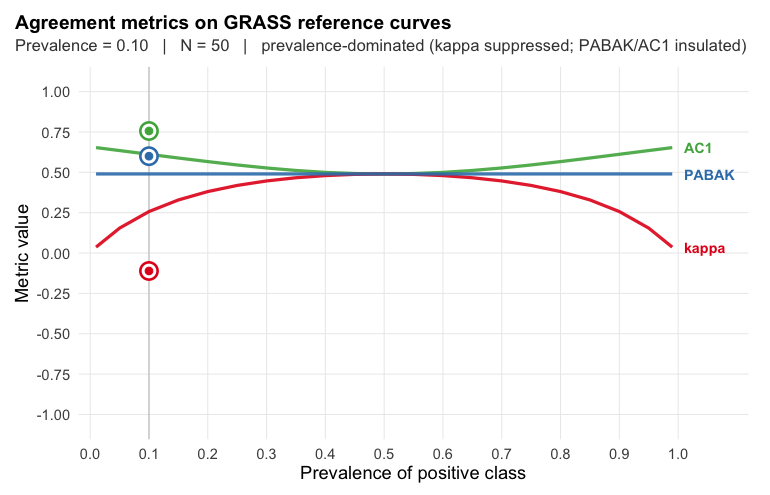

```r
plot(result_rare)
```

grass-intro.R

Three curves show where κ, PABAK, and AC1 tend to fall across prevalence for raters at the calibrated quality level. The three points show where *this* study lands. Reading the plot is qualitative and visual — the user does the interpretation, the package does the bookkeeping.

## The regime plot

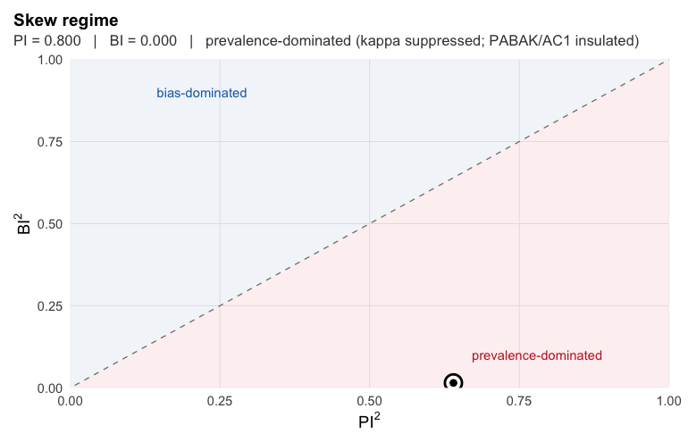

```r
plot(result_rare, type = "regime")
```

grass-intro.R

Axes are `PI²` and `BI²`. Points above the diagonal have bias dominating; points below have prevalence dominating; points near the origin are balanced. The Feinstein-Cicchetti example sits deep in the prevalence-dominated half.

## Input formats

All four shapes give identical metrics:

```r
r1 <- c(rep(0, 40), rep(0, 5), rep(1, 5))
r2 <- c(rep(0, 40), rep(1, 5), rep(0, 5))

grass_compute(list(r1, r2), format = "paired")$values["kappa"]
```

```
#>      kappa
#> -0.1111111
```

```r
grass_compute(data.frame(r1 = r1, r2 = r2), format = "wide")$values["kappa"]
```

```
#>      kappa
#> -0.1111111
```

```r
long_df <- data.frame(
  subject = rep(seq_along(r1), 2),
  rater   = rep(c("r1", "r2"), each = length(r1)),
  rating  = c(r1, r2)
)
grass_compute(long_df, format = "long")$values["kappa"]
```

```
#>      kappa
#> -0.1111111
```

grass-intro.R

Factors and character vectors are coerced to 0/1 silently with a one-time message identifying which level was mapped to the positive class. Override with `positive =`.

## What to report in a paper

For any binary inter-rater agreement study:

1. Cohen’s κ with its CI (Wilson-logit preferred — it respects the `[-1, 1]` bound at small N).
2. PABAK.
3. Gwet’s AC1.
4. Prevalence index (PI) and bias index (BI).
5. The regime label.

`as.data.frame(grass_report(...))` gives these as a one-row data.frame ready to bind to a results table.

## References

- Byrt T, Bishop J, Carlin JB. *Bias, prevalence and kappa.* J Clin Epidemiol. 1993; 46(5):423–429.
- Cohen J. *A coefficient of agreement for nominal scales.* Educ Psychol Meas. 1960; 20(1):37–46.
- Feinstein AR, Cicchetti DV. *High agreement but low kappa: I. The problems of two paradoxes.* J Clin Epidemiol. 1990; 43(6):543–549.
- Gwet KL. *Computing inter-rater reliability and its variance in the presence of high agreement.* Br J Math Stat Psychol. 2008; 61(1):29–48.
- Landis JR, Koch GG. *The measurement of observer agreement for categorical data.* Biometrics. 1977; 33(1):159–174.